# Pipelines

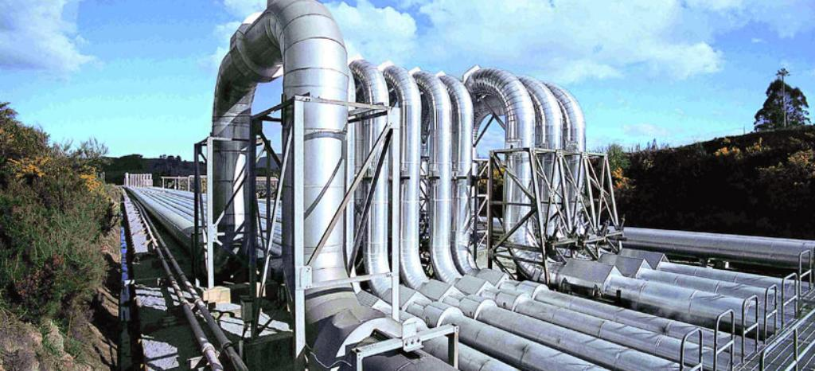

# Intro

- Heavily overloaded word
- Tasks
  - Setting up resources
  - Orchestrating workflows
  - Pulling, copying, writing data
  - Preparing training data, building ML models
  - Publishing models & making predictions

# Setup

```python
# !pip install pdpipe
```

```python
# !pip install sklearn-pandas
```

```python
import pandas as pd
import numpy as np
import matplotlib.pyplot as plt
import pdpipe as pdp

from sklearn.preprocessing import OneHotEncoder
from sklearn.preprocessing import LabelEncoder
from sklearn.preprocessing import OrdinalEncoder
from sklearn.preprocessing import StandardScaler
from sklearn.impute import SimpleImputer
from sklearn.compose import ColumnTransformer
from sklearn.pipeline import Pipeline

from sklearn.ensemble import RandomForestClassifier
from sklearn.metrics import accuracy_score
from sklearn.model_selection import train_test_split

from sklearn_pandas import DataFrameMapper

from yellowbrick.contrib.missing import MissingValuesBar
```

# Data

## Personal Data

- age (numeric)
- job : type of job (categorical)
- marital : marital status (categorical)
- education (categorical)
- default: has credit in default? (binary)
- balance: average yearly balance, in euros (numeric)
- housing: has housing loan? (binary)
- loan: has personal loan? (binary)

## Last Contact

Related with the last contact of the current campaign:

- contact: contact communication type (categorical)
- day: last contact day of the month (numeric)
- month: last contact month of year (categorical)
- duration: last contact duration, in seconds (numeric)

## Campaign

Other attributes:

- campaign: number of contacts performed during this campaign and for this client (numeric, includes last contact)
- pdays: number of days that passed by after the client was last contacted from a previous campaign (numeric)
  - -1 means client was not previously contacted)
- previous: number of contacts performed before this campaign and for this client (numeric)
- poutcome: outcome of the previous marketing campaign (categorical)

Output variable (desired target): 17 - y - has the client subscribed a term deposit? (binary: "yes","no")

```python
!kaggle datasets download -d sonujha090/bank-marketing -p ./bank-marketing
```

```
bank-marketing.zip: Skipping, found more recently modified local copy (use --force to force download)
```

```python
!unzip -o ./bank-marketing/bank-marketing.zip
```

```
Archive:  ./bank-marketing/bank-marketing.zip
  inflating: bank-full.csv
  inflating: bank.csv
```

## Read

```python
df = pd.read_csv('./bank-full.csv')
```

```python
df.head()
```

|  | age | job | marital | education | default | balance | housing | loan | contact | day | month | duration | campaign | pdays | previous | poutcome | y |
| --- | --- | --- | --- | --- | --- | --- | --- | --- | --- | --- | --- | --- | --- | --- | --- | --- | --- |
| 0 | 58 | management | married | tertiary | no | 2143 | yes | no | unknown | 5 | may | 261 | 1 | -1 | 0 | unknown | no |
| 1 | 44 | technician | single | secondary | no | 29 | yes | no | unknown | 5 | may | 151 | 1 | -1 | 0 | unknown | no |
| 2 | 33 | entrepreneur | married | secondary | no | 2 | yes | yes | unknown | 5 | may | 76 | 1 | -1 | 0 | unknown | no |
| 3 | 47 | blue-collar | married | unknown | no | 1506 | yes | no | unknown | 5 | may | 92 | 1 | -1 | 0 | unknown | no |
| 4 | 33 | unknown | single | unknown | no | 1 | no | no | unknown | 5 | may | 198 | 1 | -1 | 0 | unknown | no |

# Approach

## Initial

- Goal
- Lightweight EDA
  - Missing
  - Class balance
- Large dataset
  - Sample
- Validation strategy
  - Critical
  - Metric
  - Crossfold - Holdout
- Baseline
  - Human level performance
  - Naive baseline
  - Relate performance to cost or revenue

## Cycle

- Preprocessing Pipeline
  - Start simple
  - Incrementally add features to pipeline
- Model classifier / regressor
  - Random Forest
  - Boosting
  - Linear
  - Neural Network
- Measure progress
- Feature Importance
  - Collinear Features
  - Partial Dependence Plots
  - Tree Explainer
  - Errors
  - More EDA
- Feature Engineering & Selection
  - Removing collinear features
  - Removing unimportant features
  - Interactions
  - Incrementally add to pipeline
- Hypertuning

## Candidate

- Run against entire data set
- Deployment plans
- Story - Relating model to metric & business

# EDA

## Balance

- Classes are imbalanced
- Best plan would be to upsample or use weighting on minority

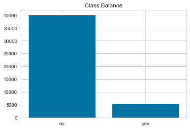

```python
grp = df.groupby('y').size()
plt.bar(grp.index, grp)
plt.title('Class Balance')
```

## Missing

- Show count of missing data by column

```python
df.isna().sum()
```

```
age          0
job          0
marital      0
education    0
default      0
balance      0
housing      0
loan         0
contact      0
day          0
month        0
duration     0
campaign     0
pdays        0
previous     0
poutcome     0
y            0
dtype: int64
```

## Types

- Change string to categories

```python
df.dtypes
```

```
age           int64
job          object
marital      object
education    object
default      object
balance       int64
housing      object
loan         object
contact      object
day           int64
month        object
duration      int64
campaign      int64
pdays         int64
previous      int64
poutcome     object
y            object
dtype: object
```

## Campaign

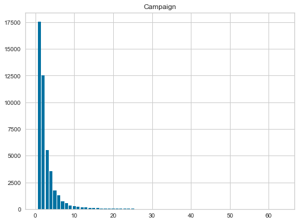

```python
grp = df.groupby('campaign').size()
plt.figure(figsize=(8,6))
plt.bar(grp.index, grp)
plt.title('Campaign')
```

## Age

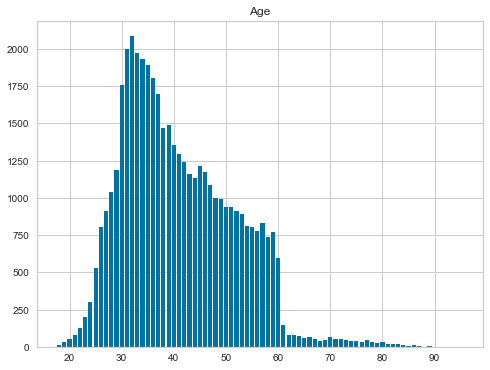

```python
grp = df.groupby('age').size()
plt.figure(figsize=(8,6))
plt.bar(grp.index, grp)
plt.title('Age')
```

# Criteria

- Works with Pandas (small - medium sized tasks)
- Works with SKLearn Estimators
- Can handle workflow -- Train, Test, Production
- Extensible -- Easy to extend for custom needs
- Compatible -- Can reuse specialized libraries

# Transformations

- Missing
  - Continuous - Median
  - Categorical - Most Frequent
  - Present Column
- Binning
  - Age
- One Hot Encoding
  - Job
  - Eduation
  - Default
  - Housing
  - Loan
  - Contact
  - Poutcome
  - Age Bin (Chained to Binning)
- Label / Ordinal Encoding
  - Day
  - Month
- Standardize / Normalize
  - Balance
  - Duration
  - Campaign
  - Previous
- Custom Logic
  - Pdays

# Pandas

## Data

```python
df = pd.read_csv('./bank-full.csv')
```

```python
df.dtypes
```

```
age           int64
job          object
marital      object
education    object
default      object
balance       int64
housing      object
loan         object
contact      object
day           int64
month        object
duration      int64
campaign      int64
pdays         int64
previous      int64
poutcome     object
y            object
dtype: object
```

## Categories

```python
for c in df.select_dtypes('object'):
    df[c] = df[c].astype('category')
df['day'] = df['day'].astype('category')
```

## Test / Train

```python
y = df['y']
X = df.drop(columns=['y'])
X_train, X_test, y_train, y_test = train_test_split(X, y, test_size=0.2, random_state=89)
X_train = X_train.copy()
X_test  = X_test.copy()
```

## Standardize

- We need to scale our training data, and apply the transformation to the test data
- Standardization - subtract mean and divide by std deviation

```python
def standardize(train, test):
    mean = train.mean()
    std = train.std()
    train = (train - mean) / std
    test  = (test - mean)  / std
    return (train, test, mean, std)
```

```python
cols = ['balance', 'previous', 'duration', 'campaign']
for col in cols:
    train, test, _, _ = standardize(X_train[col], X_test[col])
    X_train[col] = train
    X_test[col]  = test
```

## Impute Median

- Impute after standardizing

```python
def imputeMedian(train, test, col):
    med = train[col].median()
    train[col].fillna(med)
    test[col].fillna(med)
    return med
```

```python
cols = ['balance', 'previous', 'duration', 'campaign']
for col in cols:
    imputeMedian(X_train, X_test, col)
```

## Binning

```python
bins = [0,30,40,50,60,100]
X_train['age_bin'] = pd.cut(X_train.age, bins)
X_test['age_bin']  = pd.cut(X_test.age,  bins)

X_train = X_train.drop(columns=['age'])
X_test  = X_test.drop(columns=['age']);
```

## One Hot Encoding

```python
ohe = ['job', 'marital', 'education', 'default', 'housing', 'loan', 'contact', 'poutcome', 'age_bin']
X_train = pd.get_dummies(data=X_train, columns=ohe, prefix=ohe)
X_test  = pd.get_dummies(data=X_test,  columns=ohe, prefix=ohe)
assert X_train.shape[1] == X_test.shape[1]
```

## Label / Ordinal Encoding

```python
le = ['day', 'month']
for label in le:
    X_train[label] = X_train[label].cat.codes
    X_test[label]  = X_test[label].cat.codes
```

## PDays

```python
X_train['pdays_present'] = np.where(X_train.pdays == -1, 0, 1)
X_test ['pdays_present'] = np.where(X_test.pdays == -1, 0, 1)
```

## Shape

```python
print(f'Train f{X_train.shape}')
print(f'Test f{X_test.shape}')
```

[output not shown]

## Model

```python
rf = RandomForestClassifier(n_estimators=50, random_state=50)
rf.fit(X_train, y_train)
pred = rf.predict(X_test)
acc = accuracy_score(pred, y_test)
print(f'Accuracy {acc:.3f}')
```

```
Accuracy 0.903
```

## Importance

```python
pd.DataFrame({'Feature': X_train.columns, 'Importance': rf.feature_importances_}) \
.sort_values('Importance', ascending=False).head(10)
```

|  | Feature | Importance |
| --- | --- | --- |
| 3 | duration | 0.280703 |
| 0 | balance | 0.111079 |
| 1 | day | 0.092340 |
| 2 | month | 0.084521 |
| 37 | poutcome_success | 0.048429 |
| 4 | campaign | 0.042800 |
| 5 | pdays | 0.038692 |
| 6 | previous | 0.017679 |
| 43 | age_bin_(60, 100] | 0.014306 |
| 28 | housing_no | 0.013538 |

## Discussion

- Easy to iteratively experiment
- Have to remember train vs test and where to apply feature changes
- Production deployment requires transformation code and saving data (standardizing parameters & levels)
- Fluent libraries like PyJanitor can be helpful

# Sklearn Pipeline

## Data

```python
df = pd.read_csv('./bank-full.csv')
```

## Binning

```python
bins = [0,30,40,50,60,100]
df['age_bin'] = pd.cut(df.age, bins)
df['age_bin'] = df['age_bin'].astype(str)
df = df.drop(columns=['age'])
```

## PDays

```python
df['pdays_present'] = np.where(df.pdays == -1, 0, 1)
```

## Test / Train

```python
y = df['y']
X = df.drop(columns=['y'])
X_train, X_test, y_train, y_test = train_test_split(X, y, test_size=0.2, random_state=89)
X_train = X_train.copy()
X_test  = X_test.copy()
```

## Pipeline

```python
numFeatures    = ['balance', 'previous', 'duration', 'campaign']
numTransformer = Pipeline(steps=[
    ('scaler',  StandardScaler()),
    ('imputer', SimpleImputer(strategy='median'))
])

oheFeatures    = ['job', 'marital', 'education', 'default', 'housing', 'loan', 'contact', 'poutcome', 'age_bin']
oheTransformer = Pipeline(steps=[
    ('ohe', OneHotEncoder())
])

ordFeatures    = ['month', 'day']
ordTransformer = Pipeline(steps=[
    ('le', OrdinalEncoder())
])

preprocessor = ColumnTransformer(transformers=[
    ('num', numTransformer, numFeatures),
    ('ohe', oheTransformer, oheFeatures),
    ('le',  ordTransformer,  ordFeatures)
])

rf = RandomForestClassifier(n_estimators=50, random_state=50)
clf = Pipeline(steps=[('preprocessor', preprocessor),
                      ('classifier',   rf)])
```

## Model

```python
clf.fit(X_train, y_train)
preds  = clf.predict(X_test)
acc = accuracy_score(pred, y_test)
print(f'Accuracy {acc:.3f}')
```

```
Accuracy 0.902
```

## Importance

```python
pd.DataFrame({'Feature': np.arange(rf.n_features_), 'Importance': rf.feature_importances_}) \
.sort_values('Importance', ascending=False).head(10)
```

|  | Feature | Importance |
| --- | --- | --- |
| 2 | 2 | 0.283811 |
| 0 | 0 | 0.116124 |
| 42 | 42 | 0.097160 |
| 41 | 41 | 0.089485 |
| 34 | 34 | 0.051197 |
| 3 | 3 | 0.045699 |
| 1 | 1 | 0.027506 |
| 40 | 40 | 0.014510 |
| 25 | 25 | 0.013111 |
| 37 | 37 | 0.012378 |

## Discussion

- Code greatly streamlined
- Production code is easily handled (train vs test abstracted with fit & transform)
- Output is NDArray, we lose column names making importance painful to reconstruct

# DataFrameMapper

- Billed as aproviding a bridge between Sklearn's ML methods and Pandas DataFrames
- Provides a means to map DataFrame columns to transformations
- Adds transformers for working with Pandas
  - CategoricalImputer
  - FunctionTransformer

## Data

```python
df = pd.read_csv('./bank-full.csv')
```

## Binning

- Candidate for FunctionTransformer

```python
bins = [0,30,40,50,60,100]
df['age_bin'] = pd.cut(df.age, bins)
df['age_bin'] = df['age_bin'].astype(str)
df = df.drop(columns=['age'])
```

## PDays

- Candidate for FunctionTransformer

```python
df['pdays_present'] = np.where(df.pdays == -1, 0, 1)
```

## Test Train

```python
y = df['y']
X = df.drop(columns=['y'])
X_train, X_test, y_train, y_test = train_test_split(X, y, test_size=0.2, random_state=89)
X_train = X_train.copy()
X_test  = X_test.copy()
```

## Mapper

- There is a convenience function (gen_features) for applying one transformer to multiple columns
- There is support for applying multiple transformers to the same column

```python
numFeatures    = ['balance', 'previous', 'duration', 'campaign']
oheFeatures    = ['job', 'marital', 'education', 'default', 'housing', 'loan', 'contact', 'poutcome', 'age_bin']
ordFeatures    = ['month', 'day']
```

```python
mapper = DataFrameMapper([
    (['job'], OneHotEncoder()),
    (['marital'], OneHotEncoder()),
    (['education'], OneHotEncoder()),
    (['default'], OneHotEncoder()),
    (['housing'], OneHotEncoder()),
    (['loan'], OneHotEncoder()),
    (['contact'], OneHotEncoder()),
    (['poutcome'], OneHotEncoder()),
    (['age_bin'], OneHotEncoder()),
    (['month'], OrdinalEncoder()),
    (['day'], OrdinalEncoder()),
    (['balance'], StandardScaler()),
    (['previous'], StandardScaler()),
    (['duration'], StandardScaler()),
    (['campaign'], StandardScaler()),
    (['pdays'], None),
    (['pdays_present'], None)
], df_out=True)
```

```python
X_train = mapper.fit_transform(X_train)
X_test = mapper.transform(X_test)
```

## Model

```python
rf = RandomForestClassifier(n_estimators=50, random_state=50)
rf.fit(X_train, y_train)
pred = rf.predict(X_test)
acc = accuracy_score(pred, y_test)
print(f'Accuracy {acc:.3f}')
```

```
Accuracy 0.902
```

## Importance

```python
pd.DataFrame({'Feature': X_train.columns, 'Importance': rf.feature_importances_}) \
.sort_values('Importance', ascending=False).head(10)
```

|  | Feature | Importance |
| --- | --- | --- |
| 41 | duration | 0.279526 |
| 39 | balance | 0.112832 |
| 38 | day | 0.094140 |
| 37 | month | 0.084228 |
| 42 | campaign | 0.043640 |
| 43 | pdays | 0.041393 |
| 30 | poutcome_x0_success | 0.041197 |
| 40 | previous | 0.019725 |
| 21 | housing_x0_no | 0.014780 |
| 22 | housing_x0_yes | 0.013822 |

## Discussion

- Good complement, can use SKLearn preprocessing and get data frames out
- Thought & Implementation given to cardinality of transforms and columns
- Starters for functional transformations and category imputation
- Excludes columns not mapped - you need to add a None transformer

# PDPipe

- Provides an opinionated and concise interface for building Pandas pipelines that have
  - Preconditions
  - Support fit-transform design of sklearn
  - Serializable
  - Informative prints and errors
- Simple pipeline arithmetic

## Data

```python
df = pd.read_csv('./bank-full.csv')
```

## Test / Train

```python
y = df['y']
X = df.drop(columns=['y'])
X_train, X_test, y_train, y_test = train_test_split(X, y, test_size=0.2, random_state=89)
X_train = X_train.copy()
X_test  = X_test.copy()
```

## Pipeline

```python
numFeatures    = ['balance', 'previous', 'duration', 'campaign']
oheFeatures    = ['job', 'marital', 'education', 'default', 'housing', 'loan', 'contact', 'poutcome', 'age_bin']
ordFeatures    = ['month', 'day']
```

```python
pipe     = pdp.ColByFrameFunc('pdays_present', lambda df: np.where(df.pdays == -1, 0, 1))
pipe    += pdp.Bin({'age': [0,30,40,50,60,100]})
pipe    += pdp.ColRename({'age': 'age_bin'})
pipe    += pdp.OneHotEncode(columns=oheFeatures, drop_first=False)
pipe    += pdp.Encode(columns=ordFeatures)
pipe    += pdp.Scale('StandardScaler')
```

```python
pipe
```

```
A pdpipe pipeline:
[ 0]  Applying a function to column pdays_present.
[ 1]  Bin age by [0, 30, 40, 50, 60, 100].
[ 2]  Rename column with {'age': 'age_bin'}
[ 3]  One-hot encode job, marital, education, default, housing, loan,
      contact, poutcome, age_bin
[ 4]  Encode month, day
[ 5]  Scale data.
```

```python
X_train = pipe.fit_transform(X_train, y_train)
X_test = pipe.transform(X_test)
```

```python
X_train.shape
```

```
(36168, 45)
```

## Model

```python
rf = RandomForestClassifier(n_estimators=50, random_state=50)
rf.fit(X_train, y_train)
pred = rf.predict(X_test)
acc = accuracy_score(pred, y_test)
print(f'Accuracy {acc:.3f}')
```

```
Accuracy 0.904
```

## Importance

```python
pd.DataFrame({'Feature': X_train.columns, 'Importance': rf.feature_importances_}) \
.sort_values('Importance', ascending=False).head(10)
```

|  | Feature | Importance |
| --- | --- | --- |
| 3 | duration | 0.279378 |
| 0 | balance | 0.112798 |
| 1 | day | 0.094405 |
| 2 | month | 0.085497 |
| 38 | poutcome_success | 0.046462 |
| 4 | campaign | 0.044031 |
| 5 | pdays | 0.037383 |
| 6 | previous | 0.018707 |
| 30 | housing_yes | 0.015234 |
| 41 | age_bin_30-40 | 0.012516 |

## Discussion

- From a code perspective PDPipe was the most elegant
  - Simple Interface to Transforms
  - Fluid coding made easy += operator for assembling stages
  - Succinct - not a lot of lines of code, and easy to grok
  - Fit / Transform
- Production - comparable to sklearn Pipeline
- Classifier not grouped into pipeline (Not a big pain point for me)
- Beta (nicely documented but lacking implementation in areas)
  - Lacks SimpleImputer
  - Scaler applies to all columns
- Felt sluggish on transform method for some reason
- Extensible in terms of number of stages
  - Inheriting PdPipelineStage
  - Alternatively, use AdhocPipeline & pass transform function in constructor